# CEE 218X Assigment 1

## Section 1

Create bar or line charts showing monthly total kBTUs of residential and commercial electricity and gas consumption for the Bay Area (meaning the sum of all ZIP codes in the 9 Bay Area counties) from 2017 to the latest available month (meaning a 42-column version of the plots from section 1.8).

### Load library

```r
library(tidyverse)
library(plotly)
library(sf)
library(tigris)
library(leaflet)
```

### Extract PG&E files

```r
years <- 2017:2019
quarters <- 1:4
pge_gas <- NULL
pge_elec <- NULL

for(year in years){
  for(quarter in quarters) {
    filename_elec <-
      paste0(
        "PGE_",
        year,
        "_Q",
        quarter,
        "_ElectricUsageByZip.csv"
        )
    filename_gas <-
      paste0(
        "PGE_",
        year,
        "_Q",
        quarter,
        "_GasUsageByZip.csv"
      )
    temp_elec <- read_csv(filename_elec)
    temp_gas <- read_csv(filename_gas)
    pge_elec <- rbind(pge_elec,temp_elec)
    pge_gas <- rbind(pge_gas,temp_gas)

    saveRDS(pge_elec, "pge_elec.rds")
    saveRDS(pge_gas, "pge_gas.rds")
}
}

years <- 2020
quarters <- 1:2

for(year in years){
  for(quarter in quarters) {
    filename_elec <-
      paste0(
        "PGE_",
        year,
        "_Q",
        quarter,
        "_ElectricUsageByZip.csv"
        )
    filename_gas <-
      paste0(
        "PGE_",
        year,
        "_Q",
        quarter,
        "_GasUsageByZip.csv"
      )
    temp_elec2 <- read_csv(filename_elec)
    temp_gas2 <- read_csv(filename_gas)
    pge_elec <- rbind(pge_elec,temp_elec2)
    pge_gas <- rbind(pge_gas,temp_gas2)

    saveRDS(pge_elec, "pge_elec.rds")
    saveRDS(pge_gas, "pge_gas.rds")
}
}
```

### Generate bay area zipcodes

```r
bay_county_names <-
  c(
    "Alameda",
    "Contra Costa",
    "Marin",
    "Napa",
    "San Francisco",
    "San Mateo",
    "Santa Clara",
    "Solano",
    "Sonoma"
  )

bay_counties <-
  counties("CA", cb = T, progress_bar = F) %>%
  filter(NAME %in% bay_county_names)

usa_zips <-
  zctas(cb = T, progress_bar = F)

bay_zips <-
  usa_zips %>%
  st_centroid() %>%
  .[bay_counties, ] %>%
  st_set_geometry(NULL) %>%
  left_join(usa_zips %>% select(GEOID10)) %>%
  st_as_sf()

bay_zipcodes <- bay_zips$GEOID10
```

### Summarize PG&E files

```r
pge_elec_final <-
  pge_elec %>%
  filter(
    ZIPCODE %in%
      bay_zipcodes
  ) %>%
  filter(
    CUSTOMERCLASS %in%
      c(
        "Elec- Residential",
        "Elec- Commercial"
      )
  ) %>%
  select(
    !c(TOTALCUSTOMERS, COMBINED, AVERAGEKWH)
  ) %>%
  group_by(YEAR, MONTH, CUSTOMERCLASS) %>%
  summarize(
    TOTALKWH =
      sum(
        TOTALKWH,
        na.rm = T
      )
  ) %>%
  mutate(
    TOTALKBTU =
      TOTALKWH*3.412141633
  )

pge_gas_final <-
  pge_gas %>%
  filter(
    ZIPCODE %in%
      bay_zipcodes
  ) %>%
  filter(
    CUSTOMERCLASS %in%
      c(
        "Gas- Residential",
        "Gas- Commercial"
      )
  ) %>%
  select(
    !c(TOTALCUSTOMERS, COMBINED, AVERAGETHM)
  ) %>%
  group_by(YEAR, MONTH, CUSTOMERCLASS) %>%
  summarize(
    TOTALTHM =
      sum(
        TOTALTHM,
        na.rm = T
      )
  ) %>%
  mutate(
    TOTALKBTU =
      TOTALTHM*100
  )


pge_final <- rbind(pge_gas_final,pge_elec_final)

pge_final$Date <-
  with(pge_final, sprintf("%d-%02d",YEAR,MONTH))
```

### Plot PG&E chart

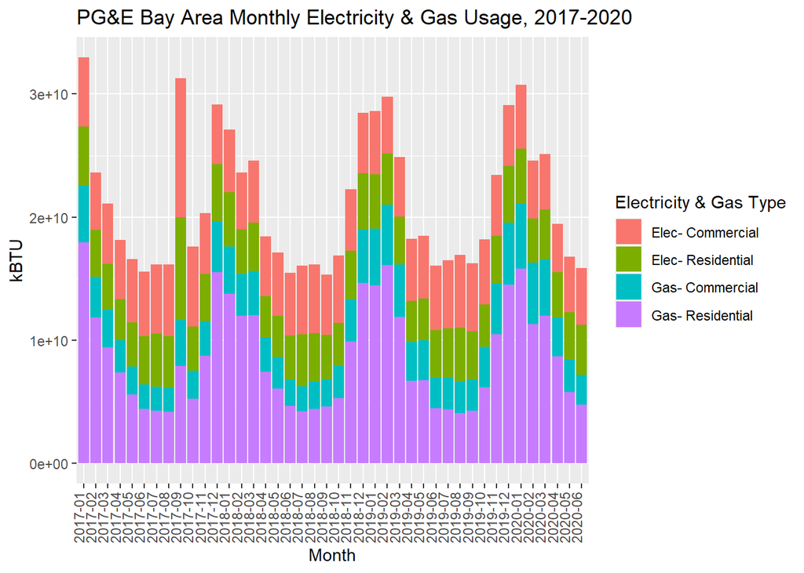

```r
pge_chart <-
  pge_final %>%
  ggplot() +
  geom_bar(
    aes(
      x = Date %>% factor(),
      y = TOTALKBTU,
      fill = CUSTOMERCLASS
    ),
    stat = "identity",
    position = "stack"
  ) +
  labs(
    x = "Month",
    y = "kBTU",
    title = "PG&E Bay Area Monthly Electricity & Gas Usage, 2017-2020",
    fill = "Electricity & Gas Type"
  ) +
  theme(axis.text.x = element_text(angle = 90, vjust = 0))

pge_chart
```

### Comment

Monthly commercial gas and electricity consumption slightly decreased during COVID (Mar 2020 - Jun 2020) comparing to the same period in 2019. This is due to the closing of many small businesses. Monthly residential gas and electricity consumption remained rather unchanged during COVID comparing to the same period in 2019.

## Section 2

Create at least one map that highlights which neighborhoods experienced the greatest change in electricity consumption before and after the pandemic began.

### Summarize electricity before and after COVID

```r
pge_elec_before <-
  pge_elec %>%
  filter(
    ZIPCODE %in%
      bay_zipcodes
  ) %>%
  filter(
    CUSTOMERCLASS %in%
      c(
        "Elec- Residential",
        "Elec- Commercial"
      )
  ) %>%
  filter(
    YEAR == 2019
  ) %>%
  filter(
    MONTH %in% c(3,4,5,6)
  ) %>%
  select(
    !c(TOTALCUSTOMERS, COMBINED, AVERAGEKWH)
  ) %>%
  group_by(ZIPCODE) %>%
  summarize(
    TOTALKWH =
      sum(
        TOTALKWH,
        na.rm = T
      )
  )

pge_elec_after <-
  pge_elec %>%
  filter(
    ZIPCODE %in%
      bay_zipcodes
  ) %>%
  filter(
    CUSTOMERCLASS %in%
      c(
        "Elec- Residential",
        "Elec- Commercial"
      )
  ) %>%
  filter(
    YEAR == 2020
  ) %>%
  filter(
    MONTH %in% c(3,4,5,6)
  ) %>%
  select(
    !c(TOTALCUSTOMERS, COMBINED, AVERAGEKWH)
  ) %>%
  group_by(ZIPCODE) %>%
  summarize(
    TOTALKWH =
      sum(
        TOTALKWH,
        na.rm = T
      )
  )
```

### Generate PG&E electricty difference file before and after COVID

```r
pge_difference <- merge(
  pge_elec_before,pge_elec_after,
  by = c("ZIPCODE")
  ) %>%
  mutate(
    ZIPCODE = ZIPCODE %>% as.character()
  ) %>%
  mutate(
    Difference = TOTALKWH.y - TOTALKWH.x
  ) %>%
  select(
    !c(TOTALKWH.y, TOTALKWH.x)
  ) %>%
  left_join(
    bay_zips %>% select(GEOID10),
    by = c("ZIPCODE" = "GEOID10")
  ) %>%
  st_as_sf() %>%
  st_transform(4326)
```

### Plot map

```r
res_pal <- colorNumeric(
  palette = "Blues",
  domain =
    pge_difference$Difference
)

map <- leaflet() %>%
  addTiles() %>%
  addPolygons(
    data = pge_difference,
    fillColor = ~res_pal(Difference),
    color = "white",
    opacity = 0.5,
    fillOpacity = 0.5,
    weight = 1,
    label = ~paste0(
      round(Difference),
      " kWh difference in ",
      ZIPCODE
    ),
    highlightOptions = highlightOptions(
      weight = 2,
      opacity = 1
    )
  ) %>%
  addLegend(
    data = pge_difference,
    pal = res_pal,
    values = ~Difference,
    title = "PG&E electricity consumption difference before and after COVID <br>kWh"
  )

map
```

[interactive chart not shown]

### Comment

The map shows the change difference between total monthly electricity consumption during COVID (Mar 2020 - Jun 2020) and that of the same period in 2019. Some other comparisons are considered but ruled out in the process: Average monthly electricity consumption in 2020 vs 2017, 2018, 2019 is discarded because the 2020 is not a full year data, it cannot be compared to monthly average of full year data as in previous years. Total monthly electricity consumption during COVID (Mar 2020 - Jun 2020) and that of the same period in 2017, 2018, and 2019 is discarded for the 2017 is way back in the past and many other factors might come in to affect the comparison rather than COVID situation alone.

From the map, we can see that most of the areas are colored in the range of light blue to white, which means small changes happen in most areas. However, in 94545 and 95014, the electricity consumption increased by quite a lot. The reason of this change requires further investigation.